# 01 DCA Giving Trends

# Goal

Examine giving trends for the Dean’s Consulting Alliance Spring 2019 group. Specifically, assess the following hypotheses:

- If a graduate disengages with Kellogg right after graduation, they don’t donate ever
- Mature alumni who donate in later career have donated as a recent grad

# Data

A [SQL query](https://github.com/phively/ksm-stats/blob/master/2019-DCA-recent-grad-giving/code/sql-giving-query.sql) was run to pull all full-time alumni (defined as program in 2Y, 1Y, MMM, JDMBA, FT) along with their program, master’s degree year, fiscal year of first gift, giving in FY13-18, and giving the fiscal year of graduation and in each of the five subsequent fiscal years.

```r
# R libraries
library(tidyverse)
library(ggplot2)
library(readxl)
library(splines)
```

```r
# Import data
giving <- read_xlsx(
  path = 'data/2019-04-29 giving data.xlsx'
  , sheet = 'With'
)
# Cleanup
giving <- giving %>% filter(
  # Drop 0 years
  FIRST_MASTERS_YEAR != '0000'
) %>% mutate(
  # Program as factor
  PROGRAM = factor(PROGRAM)
  # Year as numeric
  , FIRST_MASTERS_YEAR = as.numeric(FIRST_MASTERS_YEAR)
) %>% mutate_at(
  # Convert yearly giving totals into a 0-1 indicator column
  .vars = vars(GIVING_PFY1:GIVING_GRADYR5)
  , .funs = function(x) {
    ifelse(replace_na(x, 0) == 0, 'nondonor', 'donor') %>%
      factor() %>%
      relevel(ref = 'nondonor')
  }
)
```

## Distribution by program and year

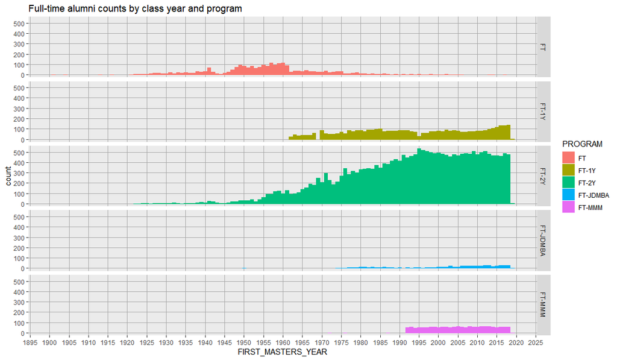

```r
giving %>%
  ggplot(aes(x = FIRST_MASTERS_YEAR, color = PROGRAM, fill = PROGRAM)) +
  geom_bar(aes(y = ..count..)) +
  facet_grid(PROGRAM ~ .) +
  scale_x_continuous(breaks = seq(0, 3000, by = 5), minor_breaks = 0:3000) +
  scale_y_continuous(breaks = seq(0, 1E5, by = 100)) +
  theme(
    panel.grid.major = element_line(color = 'darkgray')
    , panel.grid.minor = element_line(color = NA)
  ) +
  labs(title = 'Full-time alumni counts by class year and program')
```

## Donor status by year

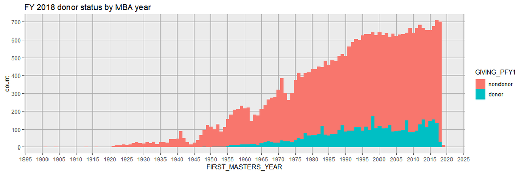

```r
giving %>%
  ggplot(aes(x = FIRST_MASTERS_YEAR, color = GIVING_PFY1, fill = GIVING_PFY1)) +
  geom_bar(aes(y = ..count..), position = 'stack') +
  scale_x_continuous(breaks = seq(0, 3000, by = 5), minor_breaks = 0:3000) +
  scale_y_continuous(breaks = seq(0, 1E5, by = 100)) +
  theme(
    panel.grid.major = element_line(color = 'darkgray')
    , panel.grid.minor = element_line(color = NA)
  ) +
  labs(title = paste('FY', min(giving$CURR_FY - 1, na.rm = TRUE), 'donor status by MBA year'))
```

# First gift year

Explore the assumption that “if a graduate disengages with Kellogg right after graduation, they don’t donate ever” by looking at the distribution of nondonors and donors, and time from graduation year until first gift year.

Begin by aggregating the data by program, MBA year, and years until the first gift was made.

```r
preagg <- giving %>% mutate(
  # Years to first gift
  yrs_to_first_gift = FIRST_GIFT_YEAR - FIRST_MASTERS_YEAR
  # Donor status
  , donor_status = ifelse(is.na(FIRST_GIFT_YEAR), 'nondonor', 'donor') %>%
    factor() %>%
    relevel(ref = 'nondonor')
  # Counter helper
  , n = 1
)
agg <- preagg %>% group_by(
  PROGRAM
  , FIRST_MASTERS_YEAR
  , donor_status
  , yrs_to_first_gift
) %>% summarise(
  n = sum(n)
)
# Save data
agg %>% write_csv(path = 'data/aggregated donor data.csv')
```

Next, examine the overall proportion of nondonors and donors.

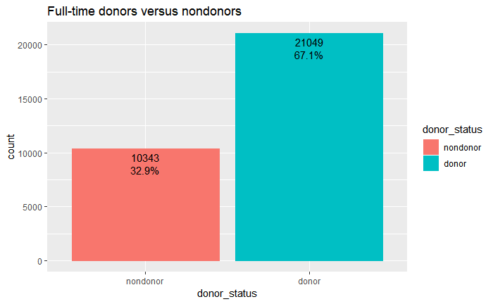

```r
preagg %>%
  ggplot(aes(x = donor_status, color = donor_status, fill = donor_status)) +
  geom_bar(aes(y = ..count..)) +
  geom_text(aes(label = ..count..)
            , stat = 'count', vjust = 1.5, color = 'black') +
  geom_text(aes(label = scales::percent(..count.. / sum(..count..)), y = ..count..)
            , stat = 'count', vjust = 3, color = 'black') +
  labs(title = 'Full-time donors versus nondonors')
```

More alumni are actually donors than nondonors.

Breaking out the donors by the number of years since graduating it took to make their first gift yields the following.

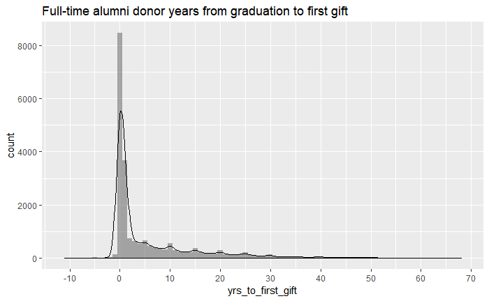

```r
preagg %>%
  filter(donor_status == 'donor') %>%
  ggplot(aes(x = yrs_to_first_gift)) +
  geom_histogram(binwidth = 1, alpha = .5) +
  geom_density(aes( y = ..count..)) +
  scale_x_continuous(breaks = seq(-1E3, 1E3, by = 10)) +
  labs(title = 'Full-time alumni donor years from graduation to first gift')
```

# Impact of early giving on later giving

For fundraising purposes, the more relevant question is whether it’s true that “mature alumni who donate in later career have donated as a recent grad.”

The most straightforward way I can think of to test this hypothesis with the data is to see whether early giving behavior can predict current-day giving after controlling for recent behavior, as well as cohort effects. In other words, if $X$ are the other explanatory variables:

$$P \left(\text{gave last year} ~ | ~ \text{gave as a recent grad}, X \right) > P \left(\text{gave last year} ~ | ~ !\text{gave as a recent grad}, X \right)$$

Define “gave last year” as making a gift in fiscal year 2018, “gave as a recent grad” as making a gift 0 through 5 fiscal years after graduation, and recent giving as making a gift in any of fiscal years 2013 through 2017.

With this in mind, I’ll restrict the analysis to only alumni graduating in or before 2007, so the full 10 years of giving history are available.

```r
glm1 <- giving %>% filter(
  FIRST_MASTERS_YEAR <= CURR_FY - 1 - 11
) %>% select(
  -ID_NUMBER, -REPORT_NAME, -DEGREES_CONCAT, -FIRST_KSM_YEAR, -CURR_FY, -FIRST_GIFT_YEAR
) %>% glm(
  GIVING_PFY1 ~ . - FIRST_MASTERS_YEAR + ns(FIRST_MASTERS_YEAR, df = 3)
  , data = .
  , family = binomial()
)
summary(glm1)
```

```
Call:
glm(formula = GIVING_PFY1 ~ . - FIRST_MASTERS_YEAR + ns(FIRST_MASTERS_YEAR,
    df = 3), family = binomial(), data = .)

Deviance Residuals:
    Min       1Q   Median       3Q      Max
-2.4060  -0.3379  -0.2918  -0.1124   2.7558

Coefficients:
                                 Estimate Std. Error z value Pr(>|z|)
(Intercept)                     -6.030081   0.667052  -9.040  < 2e-16 ***
PROGRAMFT-1Y                     1.164729   0.330304   3.526 0.000422 ***
PROGRAMFT-2Y                     1.286399   0.321765   3.998 6.39e-05 ***
PROGRAMFT-JDMBA                  1.345337   0.415557   3.237 0.001206 **
PROGRAMFT-MMM                    1.278484   0.347762   3.676 0.000237 ***
GIVING_PFY2donor                 1.974909   0.060266  32.770  < 2e-16 ***
GIVING_PFY3donor                 1.174703   0.064721  18.150  < 2e-16 ***
GIVING_PFY4donor                 0.827352   0.068060  12.156  < 2e-16 ***
GIVING_PFY5donor                 0.523093   0.069827   7.491 6.82e-14 ***
GIVING_PFY6donor                 0.987034   0.065278  15.120  < 2e-16 ***
GIVING_GRADYR0donor             -0.043261   0.070178  -0.616 0.537595
GIVING_GRADYR1donor             -0.056094   0.068425  -0.820 0.412337
GIVING_GRADYR2donor              0.009752   0.069320   0.141 0.888120
GIVING_GRADYR3donor             -0.088973   0.068726  -1.295 0.195459
GIVING_GRADYR4donor              0.077203   0.068196   1.132 0.257601
GIVING_GRADYR5donor              0.165540   0.066742   2.480 0.013127 *
ns(FIRST_MASTERS_YEAR, df = 3)1  1.634920   0.431521   3.789 0.000151 ***
ns(FIRST_MASTERS_YEAR, df = 3)2  2.799356   1.412482   1.982 0.047494 *
ns(FIRST_MASTERS_YEAR, df = 3)3  0.754880   0.224263   3.366 0.000763 ***
---
Signif. codes:  0 ‘***’ 0.001 ‘**’ 0.01 ‘*’ 0.05 ‘.’ 0.1 ‘ ’ 1

(Dispersion parameter for binomial family taken to be 1)

    Null deviance: 16806.5  on 15925  degrees of freedom
Residual deviance:  8966.5  on 15907  degrees of freedom
AIC: 9004.5

Number of Fisher Scoring iterations: 7
```

This is a binary logistic regression model predicting last year’s log odds of making a gift given the predictors. From past experience I know that the effect of graduation year is nonlinear, so I used a natural spline fit with 3 degrees of freedom (arbitrary).

Importantly, we can examine the contrasts between donor/nondonor response for each factor.

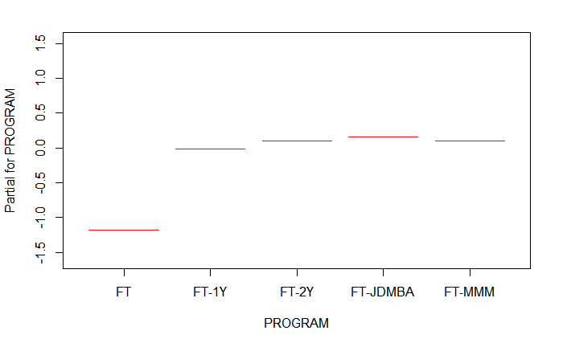

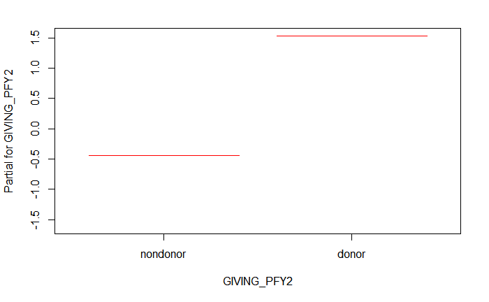

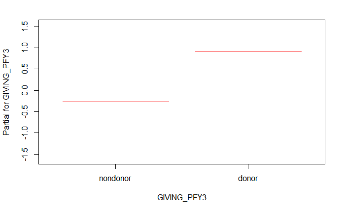

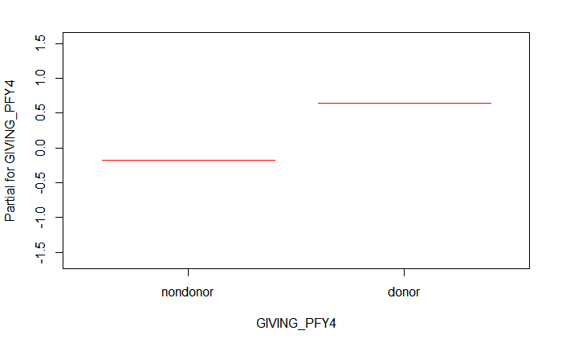

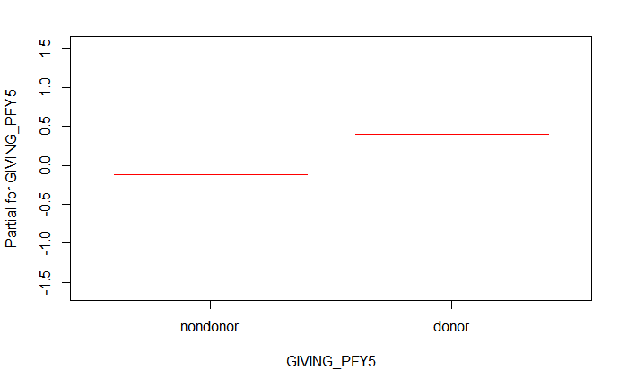

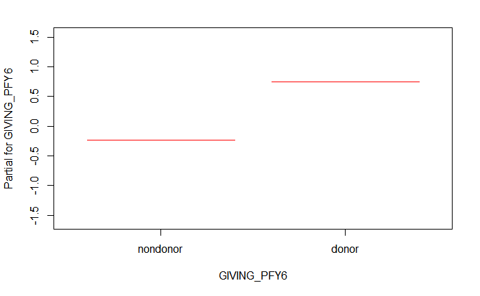

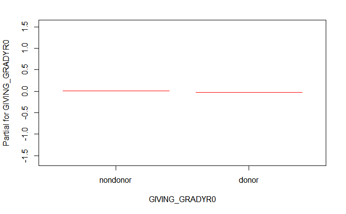

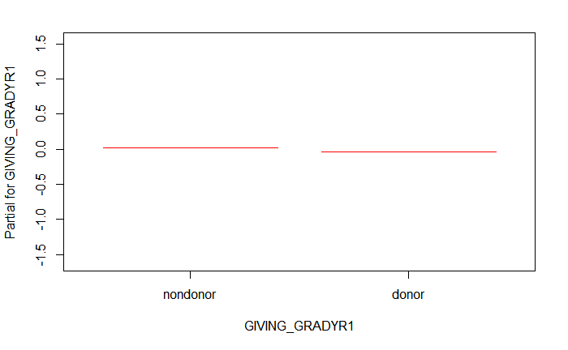

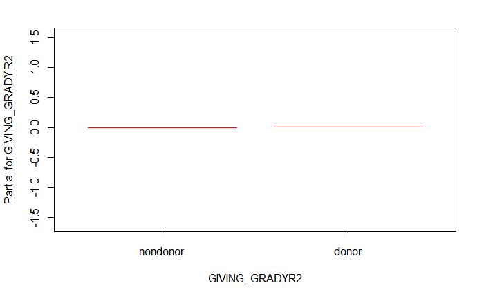

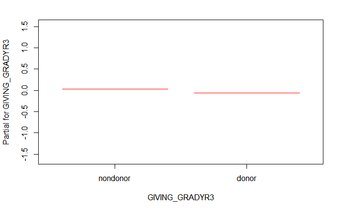

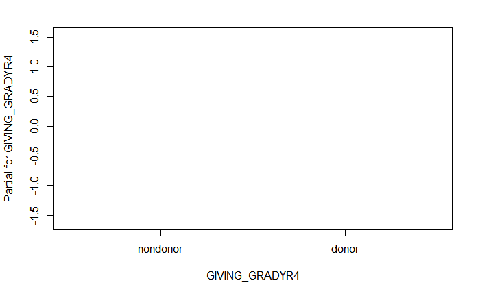

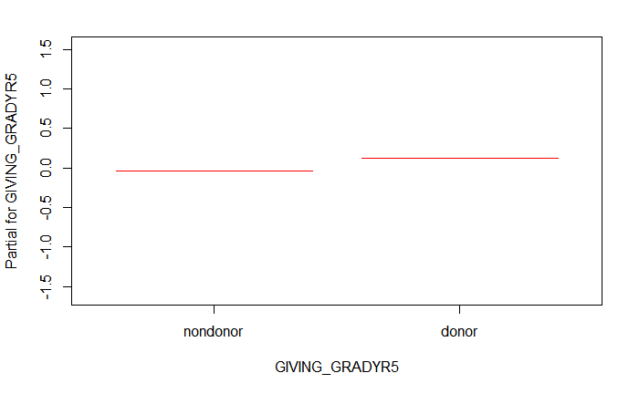

[1 more figures not shown]

```r
termplot(glm1)
```

There are large differences between each level for recent giving - GIVING_PFY2 through GIVING_PFY6 (and the coefficients are *very* statistically significant in the regression output), but almost no perceptible difference between the levels for recent alumni giving - GIVING_GRADYR0 through GIVING_GRADYR5 (and these coefficients were not statistically significant, except for the most recent, GIVING_GRADYR5).

But given that the class gift program hasn’t existed forever, perhaps there’s an interaction between recent alumni giving and graduation year.

```r
glm2 <- giving %>% filter(
  FIRST_MASTERS_YEAR <= CURR_FY - 1 - 11
) %>% select(
  -ID_NUMBER, -REPORT_NAME, -DEGREES_CONCAT, -FIRST_KSM_YEAR, -CURR_FY, -FIRST_GIFT_YEAR
) %>% glm(
  GIVING_PFY1 ~ . - FIRST_MASTERS_YEAR + ns(FIRST_MASTERS_YEAR, df = 3)
  + ns(FIRST_MASTERS_YEAR, df = 3):GIVING_GRADYR0
  + ns(FIRST_MASTERS_YEAR, df = 3):GIVING_GRADYR1
  + ns(FIRST_MASTERS_YEAR, df = 3):GIVING_GRADYR2
  + ns(FIRST_MASTERS_YEAR, df = 3):GIVING_GRADYR3
  + ns(FIRST_MASTERS_YEAR, df = 3):GIVING_GRADYR4
  + ns(FIRST_MASTERS_YEAR, df = 3):GIVING_GRADYR5
  , data = .
  , family = binomial()
)
summary(glm2)
```

```
Call:
glm(formula = GIVING_PFY1 ~ . - FIRST_MASTERS_YEAR + ns(FIRST_MASTERS_YEAR,
    df = 3) + ns(FIRST_MASTERS_YEAR, df = 3):GIVING_GRADYR0 +
    ns(FIRST_MASTERS_YEAR, df = 3):GIVING_GRADYR1 + ns(FIRST_MASTERS_YEAR,
    df = 3):GIVING_GRADYR2 + ns(FIRST_MASTERS_YEAR, df = 3):GIVING_GRADYR3 +
    ns(FIRST_MASTERS_YEAR, df = 3):GIVING_GRADYR4 + ns(FIRST_MASTERS_YEAR,
    df = 3):GIVING_GRADYR5, family = binomial(), data = .)

Deviance Residuals:
    Min       1Q   Median       3Q      Max
-2.4460  -0.3447  -0.2915  -0.1121   2.7621

Coefficients:
                                                     Estimate Std. Error z value Pr(>|z|)
(Intercept)                                          -6.25525    0.74411  -8.406  < 2e-16 ***
PROGRAMFT-1Y                                          1.15259    0.33036   3.489 0.000485 ***
PROGRAMFT-2Y                                          1.27527    0.32185   3.962 7.42e-05 ***
PROGRAMFT-JDMBA                                       1.34356    0.41551   3.234 0.001223 **
PROGRAMFT-MMM                                         1.26725    0.34811   3.640 0.000272 ***
GIVING_PFY2donor                                      1.97677    0.06064  32.601  < 2e-16 ***
GIVING_PFY3donor                                      1.17457    0.06508  18.048  < 2e-16 ***
GIVING_PFY4donor                                      0.82814    0.06831  12.123  < 2e-16 ***
GIVING_PFY5donor                                      0.52581    0.07005   7.507 6.06e-14 ***
GIVING_PFY6donor                                      0.98904    0.06539  15.126  < 2e-16 ***
GIVING_GRADYR0donor                                  -4.95947   29.46177  -0.168 0.866319
GIVING_GRADYR1donor                                   5.75916   14.66972   0.393 0.694624
GIVING_GRADYR2donor                                  -2.54098   11.97702  -0.212 0.831986
GIVING_GRADYR3donor                                   9.45267    9.91332   0.954 0.340321
GIVING_GRADYR4donor                                  -3.70098    9.20677  -0.402 0.687695
GIVING_GRADYR5donor                                  -1.01111    7.93208  -0.127 0.898568
ns(FIRST_MASTERS_YEAR, df = 3)1                       1.72432    0.45811   3.764 0.000167 ***
ns(FIRST_MASTERS_YEAR, df = 3)2                       3.33127    1.61738   2.060 0.039430 *
ns(FIRST_MASTERS_YEAR, df = 3)3                       0.81143    0.27263   2.976 0.002917 **
GIVING_GRADYR0donor:ns(FIRST_MASTERS_YEAR, df = 3)1   3.72764   21.05293   0.177 0.859461
GIVING_GRADYR0donor:ns(FIRST_MASTERS_YEAR, df = 3)2   9.00401   56.44795   0.160 0.873267
GIVING_GRADYR0donor:ns(FIRST_MASTERS_YEAR, df = 3)3   2.17002   10.77329   0.201 0.840366
GIVING_GRADYR1donor:ns(FIRST_MASTERS_YEAR, df = 3)1  -4.14311   10.35069  -0.400 0.688955
GIVING_GRADYR1donor:ns(FIRST_MASTERS_YEAR, df = 3)2 -11.11401   28.33088  -0.392 0.694842
GIVING_GRADYR1donor:ns(FIRST_MASTERS_YEAR, df = 3)3  -2.13843    5.24222  -0.408 0.683329
GIVING_GRADYR2donor:ns(FIRST_MASTERS_YEAR, df = 3)1   1.65323    8.37816   0.197 0.843573
GIVING_GRADYR2donor:ns(FIRST_MASTERS_YEAR, df = 3)2   5.15918   23.26901   0.222 0.824533
GIVING_GRADYR2donor:ns(FIRST_MASTERS_YEAR, df = 3)3   0.74788    4.19781   0.178 0.858597
GIVING_GRADYR3donor:ns(FIRST_MASTERS_YEAR, df = 3)1  -6.82466    6.89863  -0.989 0.322527
GIVING_GRADYR3donor:ns(FIRST_MASTERS_YEAR, df = 3)2 -18.34826   19.32736  -0.949 0.342447
GIVING_GRADYR3donor:ns(FIRST_MASTERS_YEAR, df = 3)3  -3.30384    3.44188  -0.960 0.337108
GIVING_GRADYR4donor:ns(FIRST_MASTERS_YEAR, df = 3)1   3.08130    6.39310   0.482 0.629825
GIVING_GRADYR4donor:ns(FIRST_MASTERS_YEAR, df = 3)2   6.73881   17.97702   0.375 0.707767
GIVING_GRADYR4donor:ns(FIRST_MASTERS_YEAR, df = 3)3   1.57743    3.17810   0.496 0.619651
GIVING_GRADYR5donor:ns(FIRST_MASTERS_YEAR, df = 3)1   0.84417    5.47364   0.154 0.877432
GIVING_GRADYR5donor:ns(FIRST_MASTERS_YEAR, df = 3)2   2.28224   15.52425   0.147 0.883123
GIVING_GRADYR5donor:ns(FIRST_MASTERS_YEAR, df = 3)3   0.23390    2.71614   0.086 0.931374
---
Signif. codes:  0 ‘***’ 0.001 ‘**’ 0.01 ‘*’ 0.05 ‘.’ 0.1 ‘ ’ 1

(Dispersion parameter for binomial family taken to be 1)

    Null deviance: 16806.5  on 15925  degrees of freedom
Residual deviance:  8959.5  on 15889  degrees of freedom
AIC: 9033.5

Number of Fisher Scoring iterations: 7
```

None of the interactions are significant. I’ll try one more approach: what about if I remove all recent giving (not recommended) and see if early giving is predictive?

```r
glm3 <- giving %>% filter(
  FIRST_MASTERS_YEAR <= CURR_FY - 1 - 11
) %>% select(
  -ID_NUMBER, -REPORT_NAME, -DEGREES_CONCAT, -FIRST_KSM_YEAR, -CURR_FY, -FIRST_GIFT_YEAR
) %>% glm(
  GIVING_PFY1 ~ . - FIRST_MASTERS_YEAR + ns(FIRST_MASTERS_YEAR, df = 3)
  - GIVING_PFY2 - GIVING_PFY3 - GIVING_PFY4 - GIVING_PFY5 - GIVING_PFY6
  , data = .
  , family = binomial()
)
summary(glm3)
```

```
Call:
glm(formula = GIVING_PFY1 ~ . - FIRST_MASTERS_YEAR + ns(FIRST_MASTERS_YEAR,
    df = 3) - GIVING_PFY2 - GIVING_PFY3 - GIVING_PFY4 - GIVING_PFY5 -
    GIVING_PFY6, family = binomial(), data = .)

Deviance Residuals:
    Min       1Q   Median       3Q      Max
-1.2249  -0.7116  -0.6163  -0.1539   3.0040

Coefficients:
                                Estimate Std. Error z value Pr(>|z|)
(Intercept)                     -3.91368    0.42390  -9.233  < 2e-16 ***
PROGRAMFT-1Y                     2.75361    0.28925   9.520  < 2e-16 ***
PROGRAMFT-2Y                     2.91064    0.28392  10.252  < 2e-16 ***
PROGRAMFT-JDMBA                  3.17352    0.33868   9.370  < 2e-16 ***
PROGRAMFT-MMM                    2.92572    0.29976   9.760  < 2e-16 ***
GIVING_GRADYR0donor             -0.08953    0.04945  -1.810 0.070235 .
GIVING_GRADYR1donor              0.03566    0.04811   0.741 0.458499
GIVING_GRADYR2donor              0.14396    0.04807   2.995 0.002748 **
GIVING_GRADYR3donor              0.23492    0.04727   4.969 6.72e-07 ***
GIVING_GRADYR4donor              0.38626    0.04674   8.265  < 2e-16 ***
GIVING_GRADYR5donor              0.70597    0.04505  15.672  < 2e-16 ***
ns(FIRST_MASTERS_YEAR, df = 3)1 -0.13892    0.26079  -0.533 0.594241
ns(FIRST_MASTERS_YEAR, df = 3)2 -1.48535    0.85816  -1.731 0.083477 .
ns(FIRST_MASTERS_YEAR, df = 3)3 -0.47157    0.14179  -3.326 0.000881 ***
---
Signif. codes:  0 ‘***’ 0.001 ‘**’ 0.01 ‘*’ 0.05 ‘.’ 0.1 ‘ ’ 1

(Dispersion parameter for binomial family taken to be 1)

    Null deviance: 16807  on 15925  degrees of freedom
Residual deviance: 15765  on 15912  degrees of freedom
AIC: 15793

Number of Fisher Scoring iterations: 6
```

We finally have some “significant” coefficients at the cost of blowing up the AIC. I find this pretty conclusive: early giving behavior is only predictive of previous year donor status when recent data is unavailable.